# Diagnosticos

Sergio Camiz

2025-05-05

```r
library(car)
library(faraway)
library(lmtest)
```

## Lectura de los datos

```r
#setwd(<aquí ponen el nombre de la carpeta donde tienen sus datos)
Decathlon           <- read.csv("Decathlon.csv",row.names=1)# lectura del archivo
labd                <- rownames(Decathlon)                  # etiquetas de las unidades en lab
nomd                <- colnames(Decathlon)                  # etiquetas de las variables en nom
nd                  <- dim(Decathlon)[1]                    # número de unidades
pd                  <- dim(Decathlon)[2]                    # número de variables
#
# Lectura de los datos
Linnerud            <- read.csv("Linnerud.csv",row.names=1) # lectura del archivo
labl                <- rownames(Linnerud)                   # etiquetas de las unidades en lab
noml                <- colnames(Linnerud)                   # etiquetas de las variables en nom
nl                  <- dim(Linnerud)[1]                     # número de unidades
pl                  <- dim(Linnerud)[2]                     # número de variables
#
# Lectura de los datos
SudAmerica          <-read.csv("SudAmerica.csv",row.names=1)# lectura del archivo
labs                <- rownames(SudAmerica)                 # etiquetas de las unidades en lab
noms                <- colnames(SudAmerica)                 # etiquetas de las variables en nom
ns                  <- dim(SudAmerica)[1]                   # número de unidades
ps                  <- dim(SudAmerica)[2]                   # número de variables
#
# Lectura de los datos
Airlines            <-read.csv("Airlines.csv")              # lectura del archivo
noma                <- colnames(Airlines)                   # etiquetas de las variables en nom
na                  <- dim(Airlines)[1]                     # número de unidades
pa                  <- dim(Airlines)[2]                     # número de variables
#
# Lectura de los datos
Ciguenas            <-read.csv("Ciguenas.csv",row.names = 1)# lectura del archivo
labc                <- rownames(Ciguenas)                   # etiquetas de las unidades en lab
nomc                <- colnames(Ciguenas)                   # etiquetas de las variables en nom
nc                  <- dim(Ciguenas)[1]                     # número de unidades
pc                  <- dim(Ciguenas)[2]                     # número de variables
```

## colinearidad

```r
cond                <- function(dat) {
  res               <- list()
  cordat            <- cor(dat)
  res$correlation   <- cordat
  eig               <- eigen(cordat)$values
  n                 <- length(eig)
  rk                <- sum(eig != 0)
  res$eigenvalues   <- eig
  res$rank          <- rk
  res$condition     <- eig[1] / eig[rk]
  invcor            <- solve(cordat)
  res$inverse.cor   <- invcor
  rmult             <- sqrt(1-1/(diag(invcor)))
  r2                <- rmult^2
  tol               <- 1 - r2
  vif               <- 1 / tol
  inf               <- cbind(rmult,r2,tol,vif)
  colnames(inf)     <- c("multiple corr.","R²","tolerance",
                         "var. inflation factor")
  res$inflation     <- inf
  res
}
```

Aplicamos la función a los datos

```r
cond(Decathlon[,1:10])
```

```
## $correlation
##                    X100m   Long.jump    Shot.put    High.jump       X400m
## X100m         1.00000000 -0.70496966 -0.36969566 -0.309283792  0.63478518
## Long.jump    -0.70496966  1.00000000  0.19545125  0.345662087 -0.67111115
## Shot.put     -0.36969566  0.19545125  1.00000000  0.612582295 -0.19930019
## High.jump    -0.30928379  0.34566209  0.61258229  1.000000000 -0.16915905
## X400m         0.63478518 -0.67111115 -0.19930019 -0.169159053  1.00000000
## X110m.hurdle  0.54255793 -0.53816329 -0.24506987 -0.325957691  0.51988045
## Discus       -0.23331691  0.24990923  0.66577435  0.516963291 -0.14418633
## Pole.vault   -0.26045206  0.28507937  0.02369214 -0.042382049 -0.11542821
## Javeline     -0.01168981  0.09379205  0.38334308  0.204481236 -0.05465387
## X1500m        0.05843441 -0.14742605  0.12954382 -0.003496111  0.55122370
##              X110m.hurdle     Discus  Pole.vault    Javeline       X1500m
## X100m          0.54255793 -0.2333169 -0.26045206 -0.01168981  0.058434406
## Long.jump     -0.53816329  0.2499092  0.28507937  0.09379205 -0.147426053
## Shot.put      -0.24506987  0.6657743  0.02369214  0.38334308  0.129543822
## High.jump     -0.32595769  0.5169633 -0.04238205  0.20448124 -0.003496111
## X400m          0.51988045 -0.1441863 -0.11542821 -0.05465387  0.551223700
## X110m.hurdle   1.00000000 -0.2168722 -0.15097483 -0.07981966  0.179045379
## Discus        -0.21687217  1.0000000 -0.18421149  0.25485350  0.220171580
## Pole.vault    -0.15097483 -0.1842115  1.00000000 -0.06610479  0.179471438
## Javeline      -0.07981966  0.2548535 -0.06610479  1.00000000 -0.251505647
## X1500m         0.17904538  0.2201716  0.17947144 -0.25150565  1.000000000
##
## $eigenvalues
##  [1] 3.5446573 1.9699560 1.4217248 0.9034912 0.5636320 0.5282270 0.4328613
##  [8] 0.3658102 0.1634956 0.1061447
##
## $rank
## [1] 10
##
## $condition
## [1] 33.39459
##
## $inverse.cor
##                    X100m  Long.jump   Shot.put   High.jump      X400m
## X100m         2.91259835  1.1855807  0.9244019 -0.07821055 -1.1079494
## Long.jump     1.18558073  3.4580144  1.4973228 -0.99019560  1.8561098
## Shot.put      0.92440193  1.4973228  3.3428998 -1.32312911  1.0656864
## High.jump    -0.07821055 -0.9901956 -1.3231291  2.13502416 -1.0795062
```

[output cut: 15 more lines]

```
## Javeline       0.04897393 -0.21736148 -0.05442458  1.62337472  1.04756620
## X1500m        -0.02974381 -0.98196378 -0.54909261  1.04756620  3.05707794
##
## $inflation
##              multiple corr.        R² tolerance var. inflation factor
## X100m             0.8103480 0.6566640 0.3433360              2.912598
## Long.jump         0.8430995 0.7108167 0.2891833              3.458014
## Shot.put          0.8371729 0.7008585 0.2991415              3.342900
## High.jump         0.7291236 0.5316212 0.4683788              2.135024
## X400m             0.8887842 0.7899374 0.2100626              4.760487
## X110m.hurdle      0.6248894 0.3904868 0.6095132              1.640654
## Discus            0.7750347 0.6006788 0.3993212              2.504250
## Pole.vault        0.5412023 0.2928999 0.7071001              1.414227
## Javeline          0.6196768 0.3839993 0.6160007              1.623375
## X1500m            0.8202989 0.6728902 0.3271098              3.057078
```

Se resulta un condicionamiento muy fuerte: más que 33. Efectivamente, X400m tiene una correlación múltiple de 0.89, con un VIF de 4.76. Intentamos de tirarlo:

```r
cond(Decathlon[,c(1:4,6:10)])
```

```
## $correlation
##                    X100m   Long.jump    Shot.put    High.jump X110m.hurdle
## X100m         1.00000000 -0.70496966 -0.36969566 -0.309283792   0.54255793
## Long.jump    -0.70496966  1.00000000  0.19545125  0.345662087  -0.53816329
## Shot.put     -0.36969566  0.19545125  1.00000000  0.612582295  -0.24506987
## High.jump    -0.30928379  0.34566209  0.61258229  1.000000000  -0.32595769
## X110m.hurdle  0.54255793 -0.53816329 -0.24506987 -0.325957691   1.00000000
## Discus       -0.23331691  0.24990923  0.66577435  0.516963291  -0.21687217
## Pole.vault   -0.26045206  0.28507937  0.02369214 -0.042382049  -0.15097483
## Javeline     -0.01168981  0.09379205  0.38334308  0.204481236  -0.07981966
## X1500m        0.05843441 -0.14742605  0.12954382 -0.003496111   0.17904538
##                  Discus  Pole.vault    Javeline       X1500m
## X100m        -0.2333169 -0.26045206 -0.01168981  0.058434406
## Long.jump     0.2499092  0.28507937  0.09379205 -0.147426053
## Shot.put      0.6657743  0.02369214  0.38334308  0.129543822
## High.jump     0.5169633 -0.04238205  0.20448124 -0.003496111
## X110m.hurdle -0.2168722 -0.15097483 -0.07981966  0.179045379
## Discus        1.0000000 -0.18421149  0.25485350  0.220171580
## Pole.vault   -0.1842115  1.00000000 -0.06610479  0.179471438
## Javeline      0.2548535 -0.06610479  1.00000000 -0.251505647
## X1500m        0.2201716  0.17947144 -0.25150565  1.000000000
##
## $eigenvalues
## [1] 3.1306621 1.7263263 1.3284705 0.8879508 0.5493504 0.4925107 0.4046088
## [8] 0.3270890 0.1530313
##
## $rank
## [1] 9
##
## $condition
## [1] 20.45766
##
## $inverse.cor
##                     X100m  Long.jump    Shot.put   High.jump X110m.hurdle
## X100m         2.654735656  1.6175693  1.17242839 -0.32945342  -0.50597653
## Long.jump     1.617569304  2.7343187  1.08181259 -0.56929699   0.34697801
## Shot.put      1.172428391  1.0818126  3.10433441 -1.08146996  -0.04170515
## High.jump    -0.329453423 -0.5692970 -1.08146996  1.89023117   0.20696104
## X110m.hurdle -0.505976534  0.3469780 -0.04170515  0.20696104   1.60814397
## Discus       -0.387038973 -0.7576665 -1.36389811 -0.18137226   0.14719935
```

[output cut: 10 more lines]

```
## Pole.vault    0.71475856  1.40974035 -0.02405010 -0.464124026
## Javeline     -0.08938953 -0.02405010  1.41773819  0.472325293
## X1500m       -0.62397925 -0.46412403  0.47232529  1.447917919
##
## $inflation
##              multiple corr.        R² tolerance var. inflation factor
## X100m             0.7895028 0.6233147 0.3766853              2.654736
## Long.jump         0.7964158 0.6342782 0.3657218              2.734319
## Shot.put          0.8233285 0.6778698 0.3221302              3.104334
## High.jump         0.6862683 0.4709642 0.5290358              1.890231
## X110m.hurdle      0.6149513 0.3781651 0.6218349              1.608144
## Discus            0.7665263 0.5875626 0.4124374              2.424610
## Pole.vault        0.5391192 0.2906495 0.7093505              1.409740
## Javeline          0.5428178 0.2946511 0.7053489              1.417738
## X1500m            0.5561952 0.3093531 0.6906469              1.447918
```

```r
cond(Decathlon[,c(1:2,4,6:10)])
```

```
## $correlation
##                    X100m   Long.jump    High.jump X110m.hurdle     Discus
## X100m         1.00000000 -0.70496966 -0.309283792   0.54255793 -0.2333169
## Long.jump    -0.70496966  1.00000000  0.345662087  -0.53816329  0.2499092
## High.jump    -0.30928379  0.34566209  1.000000000  -0.32595769  0.5169633
## X110m.hurdle  0.54255793 -0.53816329 -0.325957691   1.00000000 -0.2168722
## Discus       -0.23331691  0.24990923  0.516963291  -0.21687217  1.0000000
## Pole.vault   -0.26045206  0.28507937 -0.042382049  -0.15097483 -0.1842115
## Javeline     -0.01168981  0.09379205  0.204481236  -0.07981966  0.2548535
## X1500m        0.05843441 -0.14742605 -0.003496111   0.17904538  0.2201716
##               Pole.vault    Javeline       X1500m
## X100m        -0.26045206 -0.01168981  0.058434406
## Long.jump     0.28507937  0.09379205 -0.147426053
## High.jump    -0.04238205  0.20448124 -0.003496111
## X110m.hurdle -0.15097483 -0.07981966  0.179045379
## Discus       -0.18421149  0.25485350  0.220171580
## Pole.vault    1.00000000 -0.06610479  0.179471438
## Javeline     -0.06610479  1.00000000 -0.251505647
## X1500m        0.17947144 -0.25150565  1.000000000
##
## $eigenvalues
## [1] 2.7127125 1.5072195 1.2874322 0.8527904 0.5444107 0.4925098 0.3293767
## [8] 0.2735481
##
## $rank
## [1] 8
##
## $condition
## [1] 9.916767
##
## $inverse.cor
##                    X100m    Long.jump   High.jump X110m.hurdle     Discus
## X100m         2.21193918  1.208996119  0.07899036  -0.49022556  0.1280708
## Long.jump     1.20899612  2.357323723 -0.19242141   0.36151161 -0.2823691
## High.jump     0.07899036 -0.192421413  1.51347495   0.19243205 -0.6565192
## X110m.hurdle -0.49022556  0.361511609  0.19243205   1.60758368  0.1288761
## Discus        0.12807076 -0.282369063 -0.65651915   0.12887607  1.8253777
## Pole.vault    0.16698190 -0.425710158  0.03199415   0.08770395  0.5355053
## Javeline     -0.15434753 -0.007366449 -0.09227187  -0.04315416 -0.4283709
## X1500m        0.04004766  0.348204006  0.05345145  -0.26018412 -0.6802241
##               Pole.vault     Javeline      X1500m
## X100m         0.16698190 -0.154347526  0.04004766
## Long.jump    -0.42571016 -0.007366449  0.34820401
## High.jump     0.03199415 -0.092271874  0.05345145
## X110m.hurdle  0.08770395 -0.043154163 -0.26018412
## Discus        0.53550529 -0.428370854 -0.68022411
## Pole.vault    1.35611887 -0.125452328 -0.48094901
## Javeline     -0.12545233  1.225979000  0.44050800
## X1500m       -0.48094901  0.440507999  1.44263869
##
## $inflation
##              multiple corr.        R² tolerance var. inflation factor
## X100m             0.7402081 0.5479080 0.4520920              2.211939
## Long.jump         0.7588084 0.5757901 0.4242099              2.357324
## High.jump         0.5824679 0.3392689 0.6607311              1.513475
## X110m.hurdle      0.6147751 0.3779484 0.6220516              1.607584
## Discus            0.6724345 0.4521682 0.5478318              1.825378
## Pole.vault        0.5124466 0.2626015 0.7373985              1.356119
## Javeline          0.4293313 0.1843253 0.8156747              1.225979
## X1500m            0.5539185 0.3068257 0.6931743              1.442639
```

todavía el número de condicionamiento muy alto, que se arregla solo tirando el lanzamiento del pes.

Vemos ora el caso de Linnerud:

```r
cond(Linnerud[,1:3])
```

```
## $correlation
##            Weight      Waist      Pulse
## Weight  1.0000000  0.8702435 -0.3657620
## Waist   0.8702435  1.0000000 -0.3528921
## Pulse  -0.3657620 -0.3528921  1.0000000
##
## $eigenvalues
## [1] 2.1041304 0.7662277 0.1296418
##
## $rank
## [1] 3
##
## $condition
## [1] 16.23034
##
## $inverse.cor
##            Weight      Waist     Pulse
## Weight  4.1885553 -3.5460236 0.2806507
## Waist  -3.5460236  4.1443047 0.1654917
## Pulse   0.2806507  0.1654917 1.1610521
##
## $inflation
##        multiple corr.        R² tolerance var. inflation factor
## Weight      0.8724988 0.7612542 0.2387458              4.188555
## Waist       0.8710367 0.7587050 0.2412950              4.144305
## Pulse       0.3724409 0.1387122 0.8612878              1.161052
```

El condicionamiento es alto, pero no como antes. De todo modo puede ser útil tirar le peso, que tiene el VIF más alto.

```r
cond(Linnerud[,2:3])
```

```
## $correlation
##            Waist      Pulse
## Waist  1.0000000 -0.3528921
## Pulse -0.3528921  1.0000000
##
## $eigenvalues
## [1] 1.3528921 0.6471079
##
## $rank
## [1] 2
##
## $condition
## [1] 2.090675
##
## $inverse.cor
##           Waist     Pulse
## Waist 1.1422473 0.4030901
## Pulse 0.4030901 1.1422473
##
## $inflation
##       multiple corr.        R² tolerance var. inflation factor
## Waist      0.3528921 0.1245329 0.8754671              1.142247
## Pulse      0.3528921 0.1245329 0.8754671              1.142247
```

Solucionado.

En fin, en el caso de aerolineas:

```r
cond(Airlines[,1:2])
```

```
## $correlation
##       Year Month
## Year     1     0
## Month    0     1
##
## $eigenvalues
## [1] 1 1
##
## $rank
## [1] 2
##
## $condition
## [1] 1
##
## $inverse.cor
##       Year Month
## Year     1     0
## Month    0     1
##
## $inflation
##       multiple corr. R² tolerance var. inflation factor
## Year               0  0         1                     1
## Month              0  0         1                     1
```

Increible, los dos regresores son independientes.

## falta de ajuste

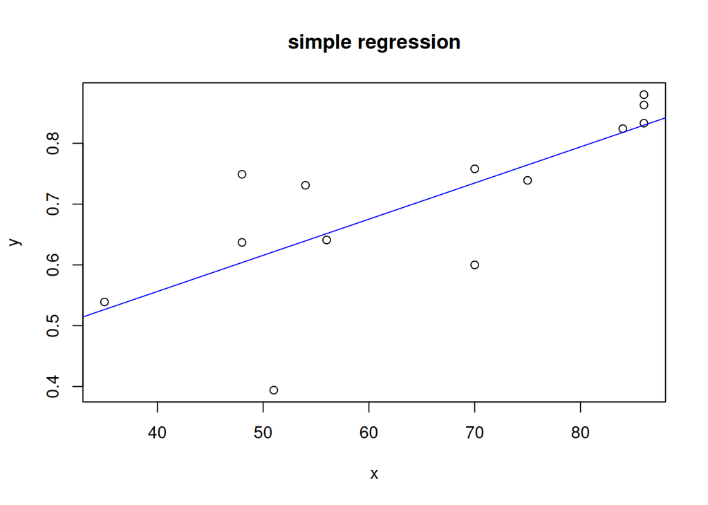

```r
y                   <- SudAmerica$IDH
x                   <- SudAmerica$Tajo_urbano
  res               <- list()
  lm1               <- lm(y~x)
  res$mod           <- summary(lm1)
  res$anova         <- anova(lm1)
  plot(x,y,main="simple regression")
    abline(lm1,col="blue")
```

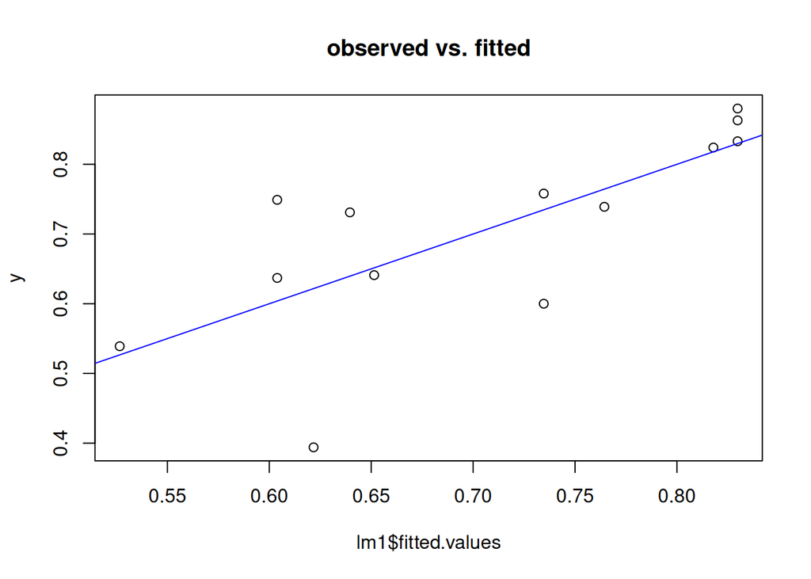

```r
  plot(lm1$fitted.values,y,main="observed vs. fitted")
    abline(0,1,col="blue")
```

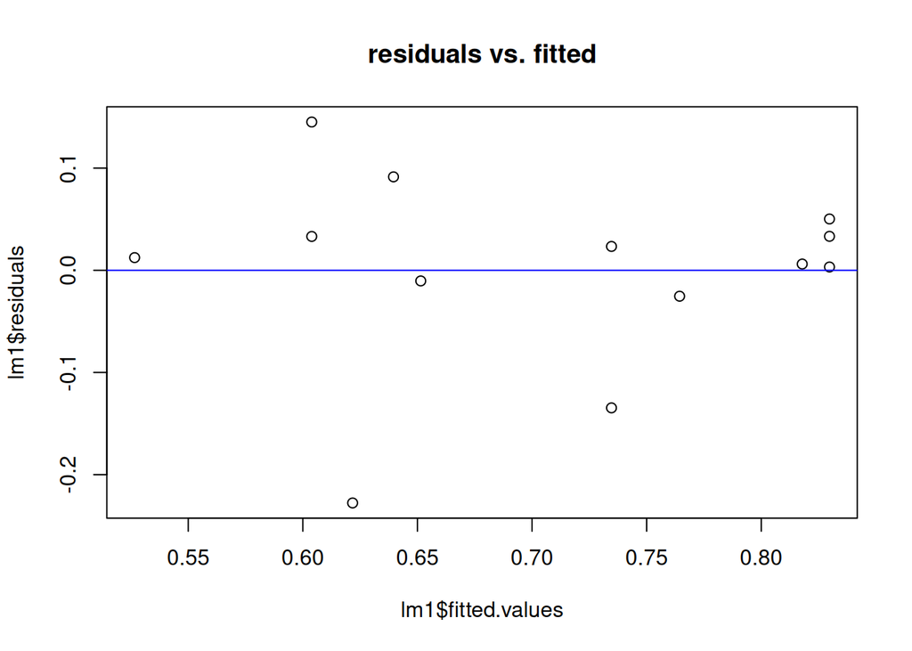

```r
  plot(lm1$fitted.values,lm1$residuals,main="residuals vs. fitted")
    abline(h=0,col="blue")
```

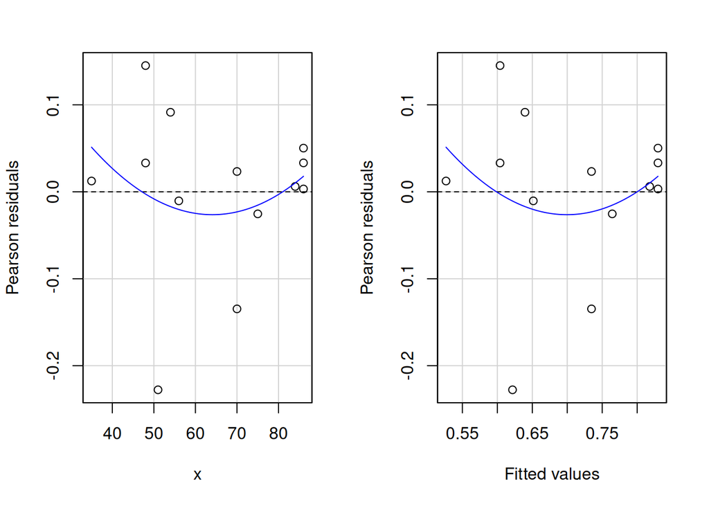

```
##            Test stat Pr(>|Test stat|)
## x             0.7634           0.4628
## Tukey test    0.7634           0.4452
```

```r
  res$tukey         <- residualPlots(lm1)                   # plot con control de linearidad
```

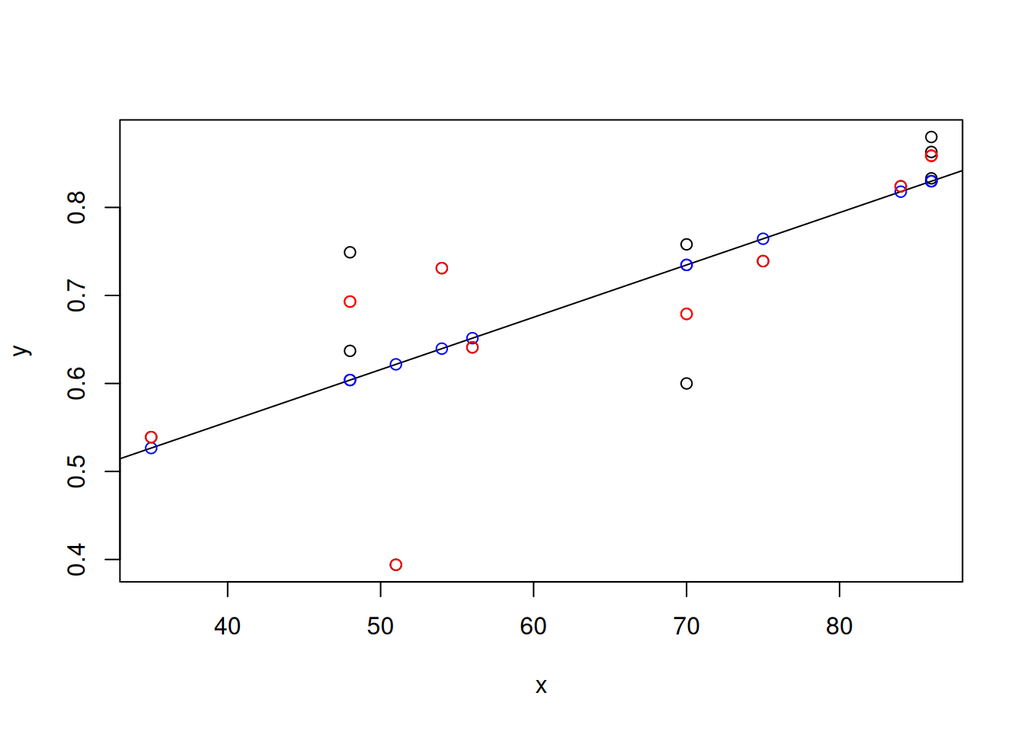

```r
  lm1f              <- lm(y ~ factor(x))                    # modelo factor
  plot(x,y)                                                 # plot comparación
    abline(lm1)
    points(x,lm1$fitted.values, col="blue")
    points(x,lm1f$fitted.values, col="red")
```

```r
  res$mod.factor    <- summary(lm1f)
  res$anova.factor  <- anova(lm1f)
  res$lack.of.fit   <- anova(lm1,lm1f)                      # comparación
  res
```

```
## $mod
##
## Call:
## lm(formula = y ~ x)
##
## Residuals:
##      Min       1Q   Median       3Q      Max
## -0.22772 -0.01044  0.01240  0.03322  0.14512
##
## Coefficients:
##             Estimate Std. Error t value Pr(>|t|)
## (Intercept) 0.318545   0.108546   2.935  0.01358 *
## x           0.005945   0.001609   3.694  0.00354 **
## ---
## Signif. codes:  0 '***' 0.001 '**' 0.01 '*' 0.05 '.' 0.1 ' ' 1
##
## Residual standard error: 0.098 on 11 degrees of freedom
## Multiple R-squared:  0.5537, Adjusted R-squared:  0.5131
## F-statistic: 13.65 on 1 and 11 DF,  p-value: 0.003537
##
##
## $anova
## Analysis of Variance Table
##
## Response: y
##           Df  Sum Sq  Mean Sq F value   Pr(>F)
## x          1 0.13106 0.131059  13.648 0.003537 **
## Residuals 11 0.10563 0.009603
## ---
## Signif. codes:  0 '***' 0.001 '**' 0.01 '*' 0.05 '.' 0.1 ' ' 1
##
## $tukey
##            Test stat Pr(>|Test stat|)
## x          0.7634136        0.4628470
## Tukey test 0.7634136        0.4452168
##
## $mod.factor
##
## Call:
## lm(formula = y ~ factor(x))
```

[output cut: 29 more lines]

```
## Response: y
##           Df   Sum Sq   Mean Sq F value  Pr(>F)
## factor(x)  8 0.216806 0.0271007   5.451 0.05946 .
## Residuals  4 0.019887 0.0049717
## ---
## Signif. codes:  0 '***' 0.001 '**' 0.01 '*' 0.05 '.' 0.1 ' ' 1
##
## $lack.of.fit
## Analysis of Variance Table
##
## Model 1: y ~ x
## Model 2: y ~ factor(x)
##   Res.Df      RSS Df Sum of Sq      F Pr(>F)
## 1     11 0.105634
## 2      4 0.019887  7  0.085747 2.4639 0.2006
```

```r
  anova(lm1)
```

```
## Analysis of Variance Table
##
## Response: y
##           Df  Sum Sq  Mean Sq F value   Pr(>F)
## x          1 0.13106 0.131059  13.648 0.003537 **
## Residuals 11 0.10563 0.009603
## ---
## Signif. codes:  0 '***' 0.001 '**' 0.01 '*' 0.05 '.' 0.1 ' ' 1
```

```r
  anova(lm1f)
```

```
## Analysis of Variance Table
##
## Response: y
##           Df   Sum Sq   Mean Sq F value  Pr(>F)
## factor(x)  8 0.216806 0.0271007   5.451 0.05946 .
## Residuals  4 0.019887 0.0049717
## ---
## Signif. codes:  0 '***' 0.001 '**' 0.01 '*' 0.05 '.' 0.1 ' ' 1
```

```r
  anova(lm1,lm1f)
```

```
## Analysis of Variance Table
##
## Model 1: y ~ x
## Model 2: y ~ factor(x)
##   Res.Df      RSS Df Sum of Sq      F Pr(>F)
## 1     11 0.105634
## 2      4 0.019887  7  0.085747 2.4639 0.2006
```

Los residuos promedios siendo 0.098 y 0.07051, du diferencia sugiere un test, pero el test de Tukey no es significativo, ni es la ANOVA entre el modelo propuesto y el modelo factorial. Por lo tanto, no hay falta de ajuste.

Por las aerolineas

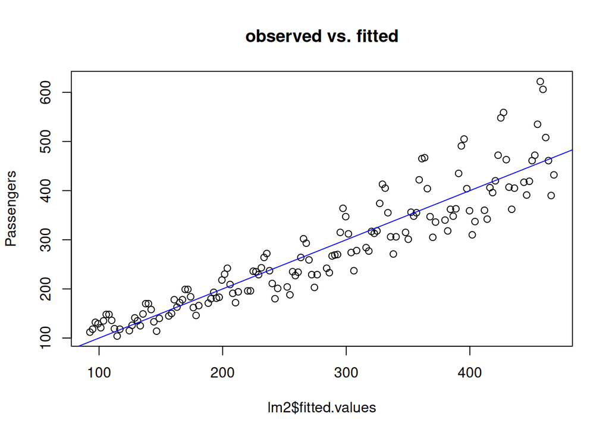

```r
res                 <- list()
  attach(Airlines)
  lm2               <- lm(Passengers~Year+Month)
  res$mod           <- summary(lm2)
  res$anova         <- anova(lm2)
  plot(lm2$fitted.values,Passengers,main="observed vs. fitted")
    abline(0,1,col="blue")
```

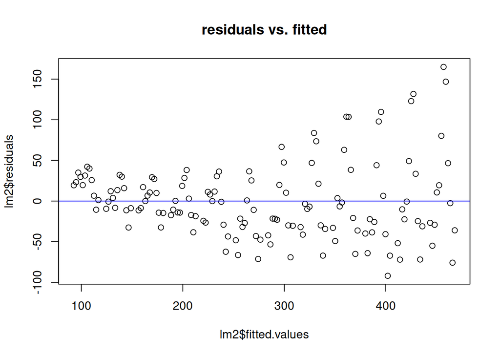

```r
  plot(lm2$fitted.values,lm2$residuals,main="residuals vs. fitted")
    abline(h=0,col="blue")
```

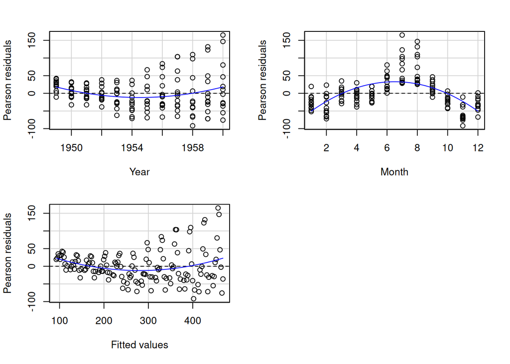

```
##            Test stat Pr(>|Test stat|)
## Year          2.7647         0.006466 **
## Month        -9.7283        < 2.2e-16 ***
## Tukey test    2.8806         0.003970 **
## ---
## Signif. codes:  0 '***' 0.001 '**' 0.01 '*' 0.05 '.' 0.1 ' ' 1
```

```r
  res$tukey         <- residualPlots(lm2)                   # plot con control de linearidad
```

```r
  lm2f              <- lm(Passengers ~ factor(Year)+factor(Month))
  res$mod.factor    <- summary(lm2f)
  res$anova.factor  <- anova(lm2f)
  res$lack.of.fit   <- anova(lm2,lm2f)                      # comparación
  detach(Airlines)
  res
```

```
## $mod
##
## Call:
## lm(formula = Passengers ~ Year + Month)
##
## Residuals:
##     Min      1Q  Median      3Q     Max
## -91.952 -30.078  -6.738  23.741 165.018
##
## Coefficients:
##               Estimate Std. Error t value Pr(>|t|)
## (Intercept) -62129.391   2179.496 -28.506   <2e-16 ***
## Year            31.924      1.115  28.629   <2e-16 ***
## Month            2.204      1.115   1.977     0.05 .
## ---
## Signif. codes:  0 '***' 0.001 '**' 0.01 '*' 0.05 '.' 0.1 ' ' 1
##
## Residual standard error: 46.19 on 141 degrees of freedom
## Multiple R-squared:  0.8538, Adjusted R-squared:  0.8517
## F-statistic: 411.8 on 2 and 141 DF,  p-value: < 2.2e-16
##
##
## $anova
## Analysis of Variance Table
##
## Response: Passengers
##            Df  Sum Sq Mean Sq  F value  Pr(>F)
## Year        1 1748842 1748842 819.5935 < 2e-16 ***
## Month       1    8338    8338   3.9074 0.05002 .
## Residuals 141  300865    2134
## ---
## Signif. codes:  0 '***' 0.001 '**' 0.01 '*' 0.05 '.' 0.1 ' ' 1
##
## $tukey
##            Test stat Pr(>|Test stat|)
## Year        2.764686     6.465646e-03
## Month      -9.728252     2.098052e-17
## Tukey test  2.880574     3.969521e-03
##
## $mod.factor
```

[output cut: 47 more lines]

```
## factor(Month)  11  218382   19853  35.813 < 2.2e-16 ***
## Residuals     121   67077     554
## ---
## Signif. codes:  0 '***' 0.001 '**' 0.01 '*' 0.05 '.' 0.1 ' ' 1
##
## $lack.of.fit
## Analysis of Variance Table
##
## Model 1: Passengers ~ Year + Month
## Model 2: Passengers ~ factor(Year) + factor(Month)
##   Res.Df    RSS Df Sum of Sq      F    Pr(>F)
## 1    141 300865
## 2    121  67077 20    233787 21.086 < 2.2e-16 ***
## ---
## Signif. codes:  0 '***' 0.001 '**' 0.01 '*' 0.05 '.' 0.1 ' ' 1
```

Se resulta una falta de ajuste, así que conviene testar un modelo con potencias de regresores.

## independencia

las observaciones en serie de tiempo son independientes si alrededor de 2 y prob alta

Solo se pueden testar los datos de Aerolineas, que oviamente no son independientes.

```r
durbinWatsonTest(lm2)
```

```
##  lag Autocorrelation D-W Statistic p-value
##    1       0.7287964     0.5368469       0
##  Alternative hypothesis: rho != 0
```

## heteroscedasticidad

no hay si prob alta, si hay con prob baja

```r
cat("\n Datos de SudAmerica \n")
```

```
##
##  Datos de SudAmerica
```

```r
bptest(lm1)                                                 # Breusch-Pagan test
```

```
##
##  studentized Breusch-Pagan test
##
## data:  lm1
## BP = 1.4566, df = 1, p-value = 0.2275
```

```r
ncvTest(lm1)                                                # NCV test
```

```
## Non-constant Variance Score Test
## Variance formula: ~ fitted.values
## Chisquare = 2.275996, Df = 1, p = 0.13139
```

```r
attach(Airlines)
cat("\n Datos de Airlines \n")
```

```
##
##  Datos de Airlines
```

```r
bptest(lm2)                                                 # Breusch-Pagan test
```

```
##
##  studentized Breusch-Pagan test
##
## data:  lm2
## BP = 27.005, df = 2, p-value = 1.368e-06
```

```r
ncvTest(lm2)                                                # NCV test
```

```
## Non-constant Variance Score Test
## Variance formula: ~ fitted.values
## Chisquare = 43.97781, Df = 1, p = 3.3212e-11
```

```r
detach(Airlines)
```

El test resulta negativo por los datos de IDH pero positivo por los de Aerolineas: este último si tiene heterocedasticidad.

## análisis de los residuos

```r
attach(Ciguenas)                                            # archivo en uso
rcic                <- lm(Birth~.,data=Ciguenas)                    # modelo
  summary(rcic); anova(rcic)
```

```
##
## Call:
## lm(formula = Birth ~ ., data = Ciguenas)
##
## Residuals:
##     Min      1Q  Median      3Q     Max
## -317.24  -52.95    2.44   73.89  295.48
##
## Coefficients:
##               Estimate Std. Error t value Pr(>|t|)
## (Intercept) -4.824e+01  5.172e+01  -0.933   0.3680
## Area         9.596e-04  3.240e-04   2.962   0.0110 *
## Storks       8.965e-03  5.024e-03   1.784   0.0977 .
## Humans       6.369e+00  2.635e+00   2.417   0.0311 *
## ---
## Signif. codes:  0 '***' 0.001 '**' 0.01 '*' 0.05 '.' 0.1 ' ' 1
##
## Residual standard error: 140.3 on 13 degrees of freedom
## Multiple R-squared:  0.9049, Adjusted R-squared:  0.8829
## F-statistic: 41.23 on 3 and 13 DF,  p-value: 6.644e-07
```

```
## Analysis of Variance Table
##
## Response: Birth
##           Df  Sum Sq Mean Sq  F value    Pr(>F)
## Area       1 2289604 2289604 116.3353 7.429e-08 ***
## Storks     1   29807   29807   1.5145    0.2403
## Humans     1  114942  114942   5.8402    0.0311 *
## Residuals 13  255854   19681
## ---
## Signif. codes:  0 '***' 0.001 '**' 0.01 '*' 0.05 '.' 0.1 ' ' 1
```

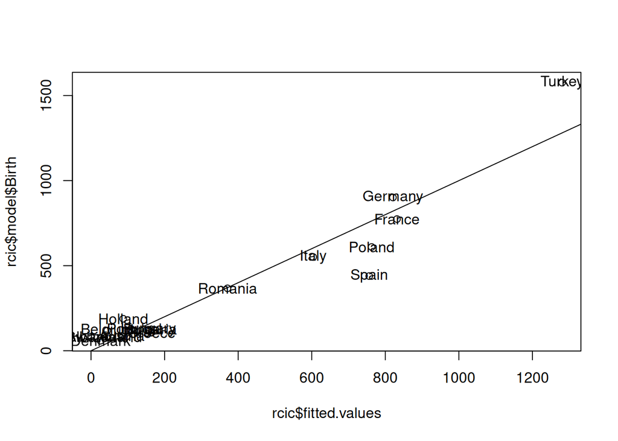

```r
# plot básicos: valores estimados
plot(rcic$fitted.values,rcic$model$Birth)                   # plot estimados-observados
  abline(0,1)
  text(rcic$fitted.values,rcic$model$Birth,lab=labc)
```

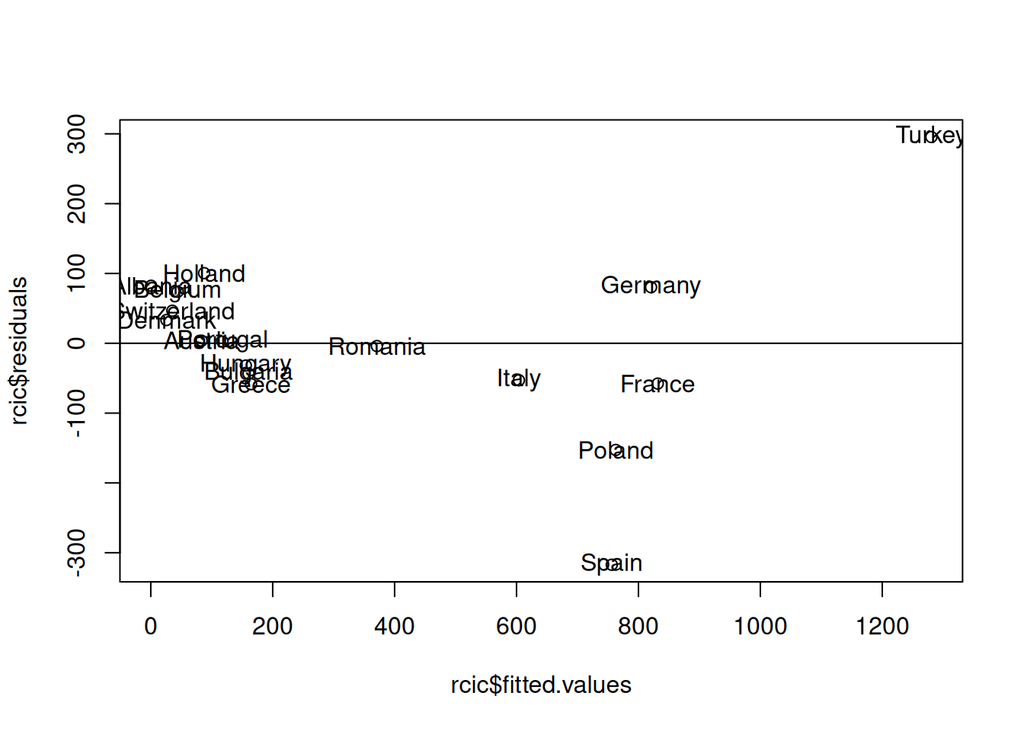

```r
# residuos
plot(rcic$fitted.values,rcic$residuals)                     #  plot estimados-residuos
  abline(h=0)
  text(rcic$fitted.values,rcic$residuals,lab=labc)
```

La regresión de los nacimientos mostra que para las cigueñas no es cierto que el beta sea diferente de cero.

Corremos el test de Tukey con los residuos:

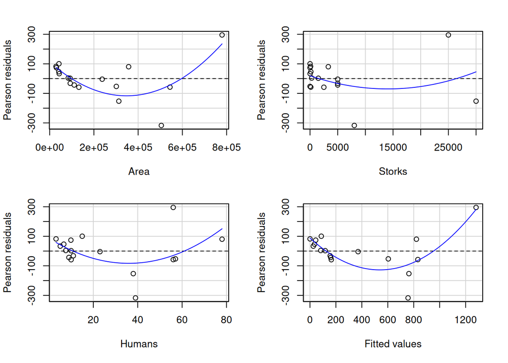

```
##            Test stat Pr(>|Test stat|)
## Area          6.6040        2.523e-05 ***
## Storks        0.8364          0.41926
## Humans        2.3402          0.03737 *
## Tukey test    7.0432        1.879e-12 ***
## ---
## Signif. codes:  0 '***' 0.001 '**' 0.01 '*' 0.05 '.' 0.1 ' ' 1
```

```r
# residuos con test de linearidad
residualPlots(rcic)                                         # plot con test
```

se resulta una falta de ajuste por Area y Humans, así que se pone el cuadrado para el Area.

```r
rcic2               <- lm(Birth~I(Area^2)+Humans,data=Ciguenas)# modelo
summary(rcic2); anova(rcic2)
```

```
##
## Call:
## lm(formula = Birth ~ I(Area^2) + Humans, data = Ciguenas)
##
## Residuals:
##      Min       1Q   Median       3Q      Max
## -290.036  -11.244    0.699   43.388  156.063
##
## Coefficients:
##              Estimate Std. Error t value Pr(>|t|)
## (Intercept) 2.888e+01  4.033e+01   0.716 0.485634
## I(Area^2)   1.596e-09  2.315e-10   6.893 7.41e-06 ***
## Humans      7.528e+00  1.576e+00   4.777 0.000295 ***
## ---
## Signif. codes:  0 '***' 0.001 '**' 0.01 '*' 0.05 '.' 0.1 ' ' 1
##
## Residual standard error: 109.8 on 14 degrees of freedom
## Multiple R-squared:  0.9373, Adjusted R-squared:  0.9283
## F-statistic: 104.7 on 2 and 14 DF,  p-value: 3.808e-09
```

```
## Analysis of Variance Table
##
## Response: Birth
##           Df  Sum Sq Mean Sq F value    Pr(>F)
## I(Area^2)  1 2246630 2246630 186.483 1.751e-09 ***
## Humans     1  274914  274914  22.819 0.0002951 ***
## Residuals 14  168663   12047
## ---
## Signif. codes:  0 '***' 0.001 '**' 0.01 '*' 0.05 '.' 0.1 ' ' 1
```

No se pude hacer una comparación, pero la calidad del modelo mejora.

Testamos la homocedasticidad de ambos modelos:

```r
# homocedasticidad                                                  cat("\n modelo 1 normal \n")
ncvTest(rcic)                                               # test NCV
```

```
## Non-constant Variance Score Test
## Variance formula: ~ fitted.values
## Chisquare = 13.69344, Df = 1, p = 0.00021521
```

```r
cat("\n modelo 2 con cuadrado \n")
```

```
##
##  modelo 2 con cuadrado
```

```r
ncvTest(rcic2)                                              # test NCV
```

```
## Non-constant Variance Score Test
## Variance formula: ~ fitted.values
## Chisquare = 10.45599, Df = 1, p = 0.0012225
```

En ambos casos se encuentra heteroscedasticidad, aún reducida en el modelo 2.

```r
cat("\n modelo 1")
```

```
##
##  modelo 1
```

```r
# normalidad
shapiro.test(rcic$residuals)                                # si es normal
```

```
##
##  Shapiro-Wilk normality test
##
## data:  rcic$residuals
## W = 0.91881, p-value = 0.141
```

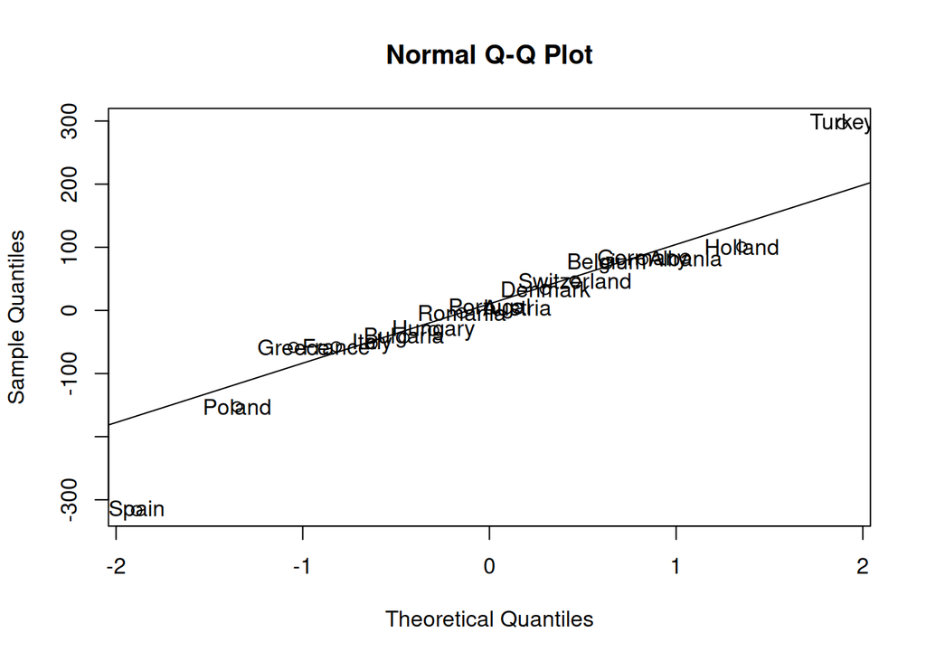

```r
re                  <-qqnorm(rcic$residuals)                # q-q plot
  qqline(rcic$residuals)
  text(re$x,re$y,lab=labc)
```

```r
cat("\n modelo 2")
```

```
##
##  modelo 2
```

```r
# normalidad
shapiro.test(rcic2$residuals)                               # si es normal
```

```
##
##  Shapiro-Wilk normality test
##
## data:  rcic2$residuals
## W = 0.87224, p-value = 0.02386
```

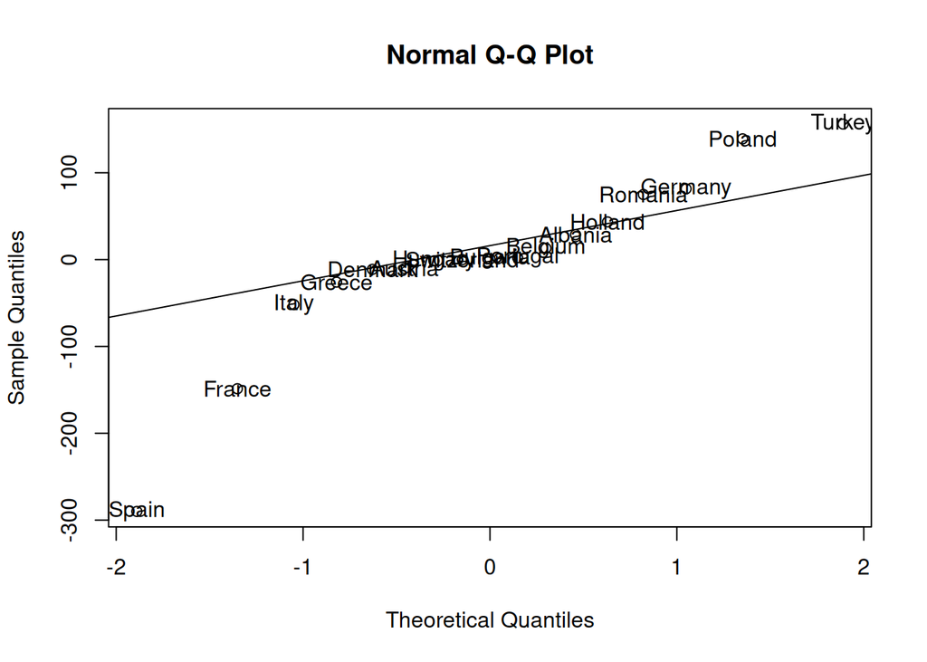

```r
re                  <- qqnorm(rcic2$residuals)              # q-q plot
  qqline(rcic2$residuals)
  text(re$x,re$y,lab=labc)
```

Se resulta que el modelo 1 tiene residuos normales, mientras el 2 no. Por tanto, seguimos con el modelo 1.

```r
# apalancamientos
influence(rcic)$hat                                         # hii
```

```
##     Albania     Austria     Belgium    Bulgaria     Denmark      France
##  0.11900848  0.10250893  0.10580913  0.09398970  0.11107498  0.38753751
##     Germany      Greece     Holland     Hungary       Italy      Poland
##  0.62722071  0.09265502  0.10791279  0.09140244  0.28282549  0.77437997
##    Portugal     Romania       Spain Switzerland      Turkey
##  0.08823535  0.06612908  0.24127770  0.10554654  0.60248618
```

```r
influence(rcic)$sigma                                       # sigma(i)
```

```
##     Albania     Austria     Belgium    Bulgaria     Denmark      France
##   143.80329   146.01341   144.26497   145.42250   145.66098   144.45783
##     Germany      Greece     Holland     Hungary       Italy      Poland
##   140.99582   144.93612   142.75303   145.69792   144.89797   112.68991
##    Portugal     Romania       Spain Switzerland      Turkey
##   146.01582   146.01284   101.32894   145.32334    54.93956
```

```r
influence(rcic)$coefficients                                # beta(i)
```

```
##              (Intercept)          Area        Storks       Humans
## Albania      11.84472112 -2.492423e-06 -1.494151e-04 -0.197248330
## Austria       0.46182144  4.352450e-07 -1.248746e-05 -0.009927957
## Belgium       9.21434200 -2.018958e-05 -5.789438e-05  0.014646336
## Bulgaria     -4.95646826  2.376689e-07 -9.604811e-05  0.100578403
## Denmark       4.55513624 -4.397298e-07 -7.632563e-05 -0.073079793
## France        2.47786199 -8.440424e-05  1.473558e-03  0.119956714
## Germany     -14.43269255 -2.157431e-04  6.511615e-05  2.901824686
## Greece       -6.59527351 -1.180917e-05  1.268511e-04  0.185956076
## Holland      11.17474682 -4.053732e-05 -4.061085e-05  0.178409849
## Hungary      -3.51182279  5.969819e-06 -1.098228e-04  0.027049211
## Italy         0.93335433  3.156442e-05  3.629237e-04 -0.549563521
## Poland       -0.09942876  7.019103e-04 -2.026214e-02 -3.576605618
## Portugal      0.28317849  4.275308e-08 -4.008191e-06 -0.004492909
## Romania      -0.27084020 -7.937221e-07  5.481581e-06  0.006518906
## Spain        -2.92353887 -3.872949e-04  2.768565e-03  1.932795488
## Switzerland   6.14228668 -4.319028e-06 -7.878957e-05 -0.067703766
## Turkey      -49.07195831  7.824111e-04  4.335249e-03 -3.952179564
```

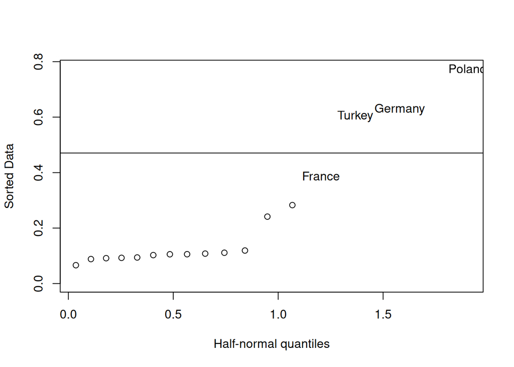

```r
halfnorm(influence(rcic)$hat,nlab=4,labs=labc)
  abline(h=2*pc/nc)
```

Turquía, Alemania y Polonia tienen apalancamiento alto, entonces tenemos que observar-los de cerca.

```r
# residuos estandarizados
rstandard(rcic)                                             # residuos
```

```
##     Albania     Austria     Belgium    Bulgaria     Denmark      France
##  0.62554539  0.02761022  0.55697132 -0.32521339  0.25186998 -0.52560926
##     Germany      Greece     Holland     Hungary       Italy      Poland
##  0.93745406 -0.43803095  0.75816180 -0.23848733 -0.44566094 -2.29284124
##    Portugal     Romania       Spain Switzerland      Turkey
##  0.01821925 -0.02937552 -2.59608144  0.35120143  3.34060473
```

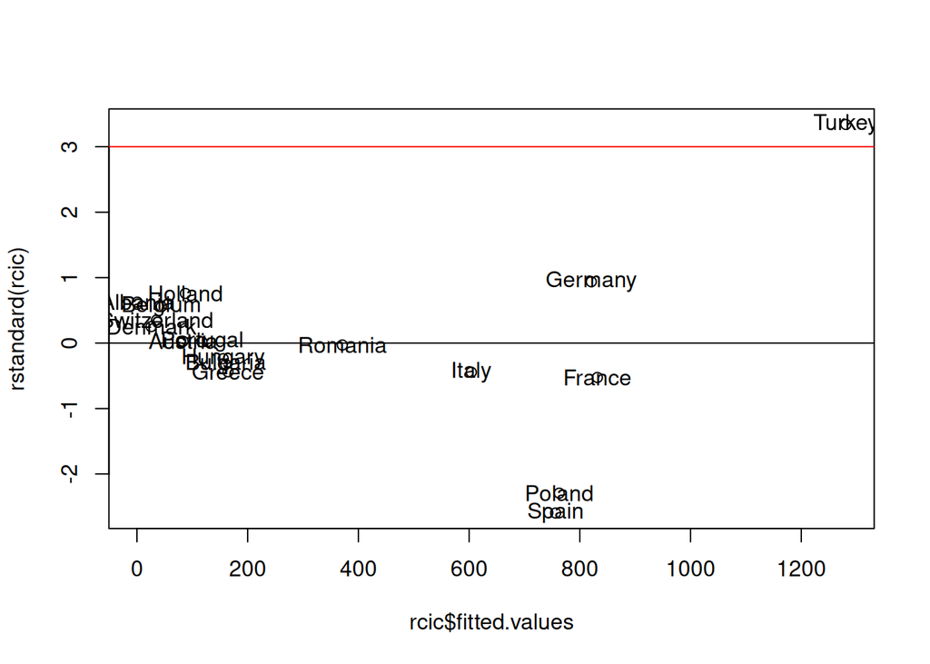

```r
plot(rcic$fitted.values,rstandard(rcic))
  abline(h=0)
  text(rcic$fitted.values,rstandard(rcic),lab=labc)
  abline(h=3,col="red")
  abline(h=-3,col="red")
```

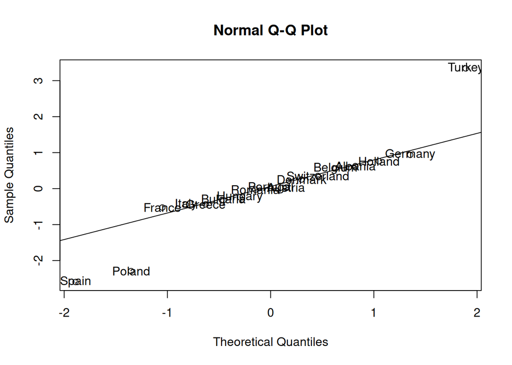

```r
res                 <- qqnorm(rstandard(rcic))              # q-q plot
  qqline(rstandard(rcic))
  text(res$x,res$y,lab=labc)
```

```r
  shapiro.test(rstandard(rcic))                             # si es normal
```

```
##
##  Shapiro-Wilk normality test
##
## data:  rstandard(rcic)
## W = 0.8789, p-value = 0.03052
```

Vemos los residuos studentizados:

```r
# residuos estudentizados
rstud               <- rstudent(rcic2); rstud
```

```
##       Albania       Austria       Belgium      Bulgaria       Denmark
##  0.2687309085 -0.0953139483  0.1205056363  0.0064298541 -0.1044526158
##        France       Germany        Greece       Holland       Hungary
## -1.5741336309  1.1289402126 -0.2390668338  0.3995265039 -0.0137491967
##         Italy        Poland      Portugal       Romania         Spain
## -0.5372675861  1.3674432624  0.0203079178  0.6920137890 -4.1421821098
##   Switzerland        Turkey
## -0.0004228482  5.2518056881
```

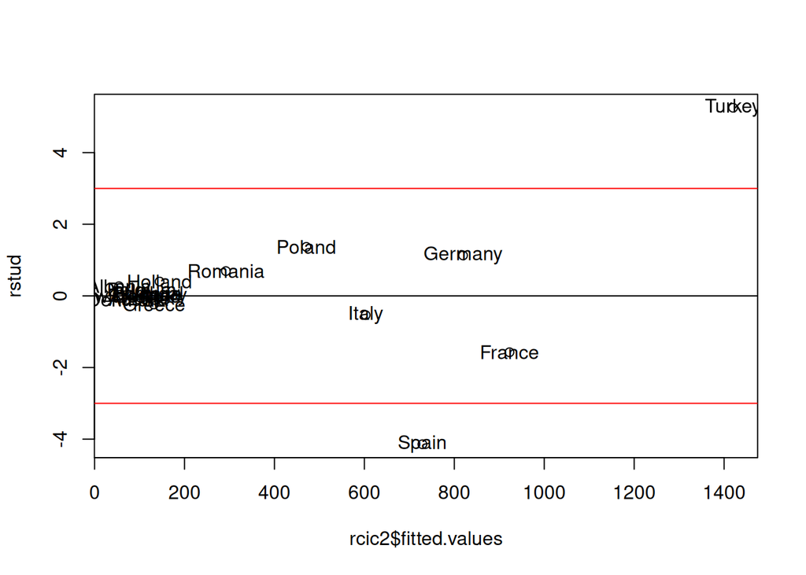

```r
plot(rcic2$fitted.values,rstud)
  abline(h=0)
  text(rcic2$fitted.values,rstud,lab=labc)
  abline(h=3,col="red")
  abline(h=-3,col="red")
```

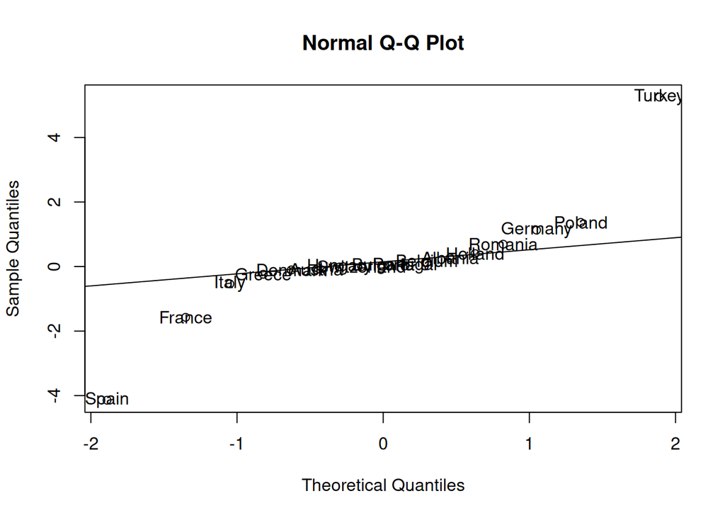

```r
rst                 <- qqnorm(rstud)                                 # normal probability plot
  qqline(rstud)
  text(rst$x,rst$y,lab=labc)
```

Se resulta que Turquía y España tienen residuos studentizados más grandes de 3. Se supone que la distribución no sea normal.

En fin, la distancia de Cook resulta la siguiente:

```r
# distancia de Cook
cd                  <- cooks.distance(rcic)
mcd                 <- mean(cd)                             # distancia promedio
cat(paste("\n distancia de Cook promedio =",mcd,"\n"))
```

```
##
##  distancia de Cook promedio = 0.574274772316052
```

```r
round(cooks.distance(rcic),3)                               # distancia de Cook
```

```
##     Albania     Austria     Belgium    Bulgaria     Denmark      France
##       0.013       0.000       0.009       0.003       0.002       0.044
##     Germany      Greece     Holland     Hungary       Italy      Poland
##       0.370       0.005       0.017       0.001       0.020       4.511
##    Portugal     Romania       Spain Switzerland      Turkey
##       0.000       0.000       0.536       0.004       4.228
```

```r
cat("\n Puntos mas lejos de 3 promedios: ")
```

```
##
##  Puntos mas lejos de 3 promedios:
```

```r
which(cooks.distance(rcic)>3*mcd)
```

```
## Poland Turkey
##     12     17
```

```r
cat("\n Puntos mas lejos de 4 veces los regresores: ")
```

```
##
##  Puntos mas lejos de 4 veces los regresores:
```

```r
which(cooks.distance(rcic)>4/nc)
```

```
## Germany  Poland   Spain  Turkey
##       7      12      15      17
```

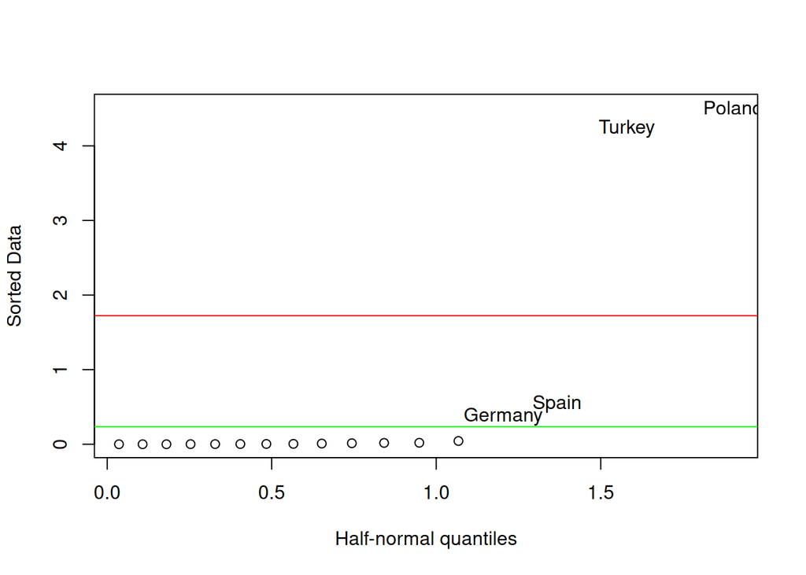

```r
halfnorm(cooks.distance(rcic),nlab=4,labs=labc)
  abline(h=3*mcd,col="red")
  abline(h=4/nc,col="green")
```

Seguramente Turquía y Polonia tienen una distancia de Cook excesiva y meritan ser tiradas. Alemania y España no parecen tan lejos.